# linear_mixed

### Data Structure for linear mixed effect model.

In this example, we have two groups (Disease vs. Control), and we measured their FIB-4 score at baseline (prior to treatment), 6 months after treatment, and 12 months after treatment. We hypothesized that the trend of FIB-4 score over time will be different between the two groups (i.e. we expect an interaction between study group and timepoints).

Here is an example of data structure for linear mixed effect model: Subject ID | Group |Time Point | Outcome ---------- | ------- |---------- | -------- 1 | 1 |1 | 10 1 | 1 |2 | 12 1 | 1 |3 | 14 2 | 0 |1 | 8 2 | 0 |2 | 10 2 | 0 |3 | 12

```python
import pandas as pd
import random

# Set a seed for reproducibility
random.seed(108)

# Generating random data
study_ids = [f'STUDY_{i}' for i in range(1, 101)]
data = []

for study_id in study_ids:
    group = random.choice(['CONTROL', 'DISEASE'])
    age = random.randint(18, 65)
    sex = random.choice(['FEMALE', 'MALE'])

    for time_block in ['BASELINE', 'POST_6M', 'POST_12M']:
        fib4 = round(random.uniform(0, 3), 2)
        data.append([study_id, group, age, sex, time_block, fib4])

# Creating DataFrame
df = pd.DataFrame(data, columns=['STUDY_ID', 'GROUP', 'AGE', 'SEX', 'TIME_BLOCK', 'FIB4'])

# Displaying the DataFrame
print(df.head())
```

```
  STUDY_ID    GROUP  AGE     SEX TIME_BLOCK  FIB4
0  STUDY_1  CONTROL   63  FEMALE   BASELINE  2.64
1  STUDY_1  CONTROL   63  FEMALE    POST_6M  1.16
2  STUDY_1  CONTROL   63  FEMALE   POST_12M  0.83
3  STUDY_2  CONTROL   23    MALE   BASELINE  0.64
4  STUDY_2  CONTROL   23    MALE    POST_6M  0.61
```

### Line graph showing the mean FIB4 score at different timepoints for each group

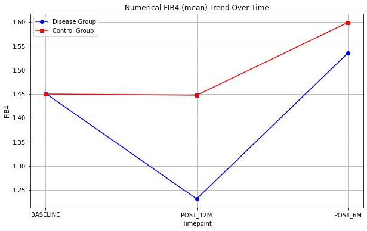

```python
import matplotlib.pyplot as plt

# Separate the data into Disease and Control groups
disease_data = df[df['GROUP'] == 'DISEASE']
control_data = df[df['GROUP'] == 'CONTROL']

# Group the data by 'Timepoint' and calculate the mean 'FIB4' value for each group
disease_grouped = disease_data.groupby('TIME_BLOCK')['FIB4'].mean()
control_grouped = control_data.groupby('TIME_BLOCK')['FIB4'].mean()

# Create a line plot to show the trend over time
plt.figure(figsize=(10, 6))

# Plot the disease group as a blue line with circles
plt.plot(disease_grouped.index, disease_grouped, label='Disease Group', marker='o', color='b')

# Plot the control group as a red line with squares
plt.plot(control_grouped.index, control_grouped, label='Control Group', marker='s', color='r')

# Add labels and legend
plt.title('Numerical FIB4 (mean) Trend Over Time')
plt.xlabel('Timepoint')
plt.xticks(disease_data['TIME_BLOCK'].unique())
plt.ylabel('FIB4')
plt.legend()

# Show the plot
plt.grid(True)
plt.savefig('meanFIB4_line_plot.png')
plt.show()
```

### What is linear mixed effect model and when should we use it?

Note that linear mixed effect quantifies the relationships between a **continuous dependent variable** and various predictor variables. Thus, for dependent variable, the linear mixed effect models assume continuous and normally distributed residuals. I will show you how to peform mixed-effects ordinal logistic regression using FIB-4 score in ordinal category in later chapter.

### Convert TIME_BLOCK in categorical to numerical so as to capture linear trend.

Since it is equal time interval between baseline, post-6m, and post-12m, we can treat it as numerical (0, 1, 2). This numerical format assume a constant rate of change in the outcome (FIB-4) over timepoint. Later in model specification, you can still do C(Timepoint) to treat Timepoint as categorical variable, so that post-6m (1) and post-12m (2) can be compared to reference timepoint baseline (0).

```python
# Define a mapping from timepoints in category to numeric values
timepoint_mapping = {
    'BASELINE': 0,
    'POST_6M': 1,
    'POST_12M': 2
}

# Use the replace method to convert timepoints to numeric values
df['TIMEPOINT'] = df['TIME_BLOCK'].replace(timepoint_mapping)

# sort by MRN and Timepoint, then reset index to start sequentially with 0
df = df.sort_values(by=['STUDY_ID', 'TIMEPOINT']).reset_index(drop=True)

# Displaying the DataFrame
print(df.head())
```

```
   STUDY_ID    GROUP  AGE     SEX TIME_BLOCK  FIB4  TIMEPOINT
0   STUDY_1  CONTROL   63  FEMALE   BASELINE  2.64          0
1   STUDY_1  CONTROL   63  FEMALE    POST_6M  1.16          1
2   STUDY_1  CONTROL   63  FEMALE   POST_12M  0.83          2
3  STUDY_10  CONTROL   21  FEMALE   BASELINE  2.67          0
4  STUDY_10  CONTROL   21  FEMALE    POST_6M  0.41          1
```

### What covariates to include the linear mixed effect model?

Our main interest is the interaction between Group (Control vs Disease) and Timepoint (0, 1, 2), because we hypothesize having the disease (fatty liver) would change the short-term (6 months) or long-term (12 months) effectiveness of the treatment of hep C (measured by FIB-4 score). This interaction effect is formulated as **GROUP*C(TIMEPOINT)** in the model. The asterisk sign indicates interaction, whereas the plus sign (+) in the model formula indicates linear effects of A + B.

In addition to GROUP*C(TIMEPOINT) interaction, we also want to control for other confounding variables that may contribute to the change of FIB-4 score over time due to the treatment, such as demographic variables like sex, age, etc. It is always a good idea to graphically see what variables differ significantly between control vs. disease group.

```python
# Convert AGE to AGE_GROUP
# Define the age range and bin size
age_range = (18, 66)
bin_size = 12

# Create bins for the specified range and size
bins = list(range(age_range[0], age_range[1] + bin_size, bin_size))

# Create labels for the age groups

labels = [f'{start}-{start + bin_size - 1}' for start in bins[:-1]]

# Use pd.cut to categorize the 'AGE_AT_INDEX' variable into 'AGE_GROUP'
df['AGE_GROUP'] = pd.cut(df['AGE'], bins=bins, labels=labels, right=False)

# Displaying the DataFrame
print(df.head())
```

```
   STUDY_ID    GROUP  AGE     SEX TIME_BLOCK  FIB4  TIMEPOINT AGE_GROUP
0   STUDY_1  CONTROL   63  FEMALE   BASELINE  2.64          0     54-65
1   STUDY_1  CONTROL   63  FEMALE    POST_6M  1.16          1     54-65
2   STUDY_1  CONTROL   63  FEMALE   POST_12M  0.83          2     54-65
3  STUDY_10  CONTROL   21  FEMALE   BASELINE  2.67          0     18-29
4  STUDY_10  CONTROL   21  FEMALE    POST_6M  0.41          1     18-29
```

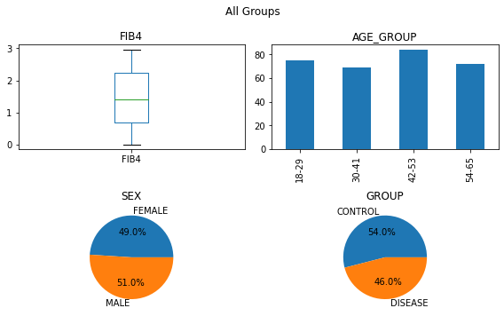

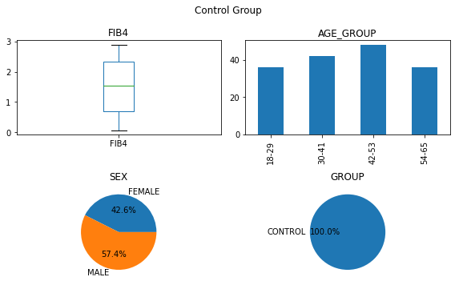

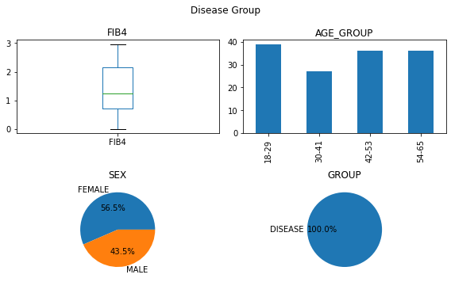

```python
import matplotlib.pyplot as plt
import numpy as np
# Function to generate the plot for a specific group
def generate_plot(data, ax):
    data['FIB4'].plot(kind='box', ax=ax[0])
    data['AGE_GROUP'].value_counts().sort_index().plot(kind='bar', ax=ax[1])
    data['SEX'].value_counts().sort_index().plot(kind='pie', autopct='%1.1f%%', ax=ax[2])
    data['GROUP'].value_counts().sort_index().plot(kind='pie', autopct='%1.1f%%', ax=ax[3])

    ax[0].set_title('FIB4')
    ax[1].set_title('AGE_GROUP')
    ax[2].set_title('SEX')
    ax[3].set_title('GROUP')
    ax[1].set_ylabel('')
    ax[2].set_ylabel('')
    ax[3].set_ylabel('')
    ax[1].set_xlabel('')

# Version for All Groups
fig, ax_all = plt.subplots(2, 2, figsize=(8, 5))
ax_all = np.ravel(ax_all)
generate_plot(df, ax_all)
fig.suptitle('All Groups')
fig.tight_layout()
fig.savefig('both_groups_plot.png')

# Version for Control Group
fig_control, ax_control = plt.subplots(2, 2, figsize=(8, 5))
ax_control = np.ravel(ax_control)
generate_plot(df[df['GROUP'] == 'CONTROL'], ax_control)
fig_control.suptitle('Control Group')
fig_control.tight_layout()
fig_control.savefig('control_group_plot.png')

# Version for Disease Group
fig_disease, ax_disease = plt.subplots(2, 2, figsize=(8, 5))
ax_disease = np.ravel(ax_disease)
generate_plot(df[df['GROUP'] == 'DISEASE'], ax_disease)
fig_disease.suptitle('Disease Group')
fig_disease.tight_layout()
fig_disease.savefig('disease_group_plot.png')

# Show the plots
plt.show()
```

## Let's create a linear mixed effect model with a random intercept and a random slope for a given group (in our case, group=STUDY_ID).

First, the "group" in this example refers to the object being measured repeatedly (i.e. STUDY_ID), not the study assignment (control vs. disease). Since there might be individual differences between groups that are not explicitly modeled by the fixed effect, we can add a random intercept to capture the difference in the baseline level of the outcome variable (FIB-4 score) across groups. In addition, there might also be difference in the steepness of the slope across groups. In our example, the hep c treatment, which administered after baseline timepoint, might have different effect on the post-6-month and post-12-month FIB-4 score across groups, with some subjects showing a steep descend slope whereas others showing a shallow descend.

- To include a random intercept for each group: re_formula="1". However, since this is the default, you don't need to explicitly specify it in the model.
- To include a random slope without a random intercept: re_formula="0+C(TIMEPOINT)"
- To include both a random intercept and a random slope while assuming dependence between the two: re_formula="1 + C(TIMEPOINT)" --> this dependence/correlation indicates that the subject with higher FIB4 at baseline tend to have steeper decline of FIB4 score over time (after treatment).
- To include both a random intercept and a random slope while assuming independence between the two: vc_formula = {'TIMEPOINT' : '0 + C(TIMEPOINT)'}

# In this linear mixed effect model, we allow both the intercept and the slope to change for each group. We also assume interactions between the intercepts and the slopes.

```python
import statsmodels.api as sm
import statsmodels.formula.api as smf

# Construct the formula with the interaction term. Here I used C(TIMEPOINT) for categorical Timepoint.
formula = "FIB4 ~ GROUP * C(TIMEPOINT) + AGE + C(SEX, Treatment(reference='FEMALE'))"

# fitting the mixed effect model (here we include a random slope and a randon intercept per group)
mixedlm_model = smf.mixedlm(formula, data=df, groups=df['STUDY_ID'], missing='drop', re_formula="1+C(TIMEPOINT)").fit()

# Print the summary of the model
print(mixedlm_model.summary())
```

```
                         Mixed Linear Model Regression Results
========================================================================================
Model:                       MixedLM            Dependent Variable:            FIB4
No. Observations:            300                Method:                        REML
No. Groups:                  100                Scale:                         0.5803
Min. group size:             3                  Log-Likelihood:                -388.7742
Max. group size:             3                  Converged:                     Yes
Mean group size:             3.0
----------------------------------------------------------------------------------------
                                              Coef.  Std.Err.   z    P>|z| [0.025 0.975]
----------------------------------------------------------------------------------------
Intercept                                      1.555    0.202  7.681 0.000  1.158  1.952
GROUP[T.DISEASE]                               0.011    0.172  0.064 0.949 -0.327  0.349
C(TIMEPOINT)[T.1]                              0.149    0.175  0.852 0.394 -0.194  0.493
C(TIMEPOINT)[T.2]                             -0.002    0.160 -0.015 0.988 -0.317  0.312
C(SEX, Treatment(reference='FEMALE'))[T.MALE]  0.080    0.100  0.796 0.426 -0.117  0.277
GROUP[T.DISEASE]:C(TIMEPOINT)[T.1]            -0.065    0.259 -0.253 0.801 -0.572  0.441
GROUP[T.DISEASE]:C(TIMEPOINT)[T.2]            -0.218    0.237 -0.921 0.357 -0.682  0.246
AGE                                           -0.004    0.004 -1.003 0.316 -0.011  0.003
Group Var                                      0.152
Group x C(TIMEPOINT)[T.1] Cov                 -0.236
C(TIMEPOINT)[T.1] Var                          0.500
Group x C(TIMEPOINT)[T.2] Cov                 -0.117
C(TIMEPOINT)[T.1] x C(TIMEPOINT)[T.2] Cov      0.251
C(TIMEPOINT)[T.2] Var                          0.230
========================================================================================
```

## We will run the same model except we assume independence between random intercepts and random slopes across groups

```python
# Construct the formula with the interaction term. Here I used C(TIMEPOINT) for categorical Timepoint.
formula = "FIB4 ~ GROUP * C(TIMEPOINT) + AGE + C(SEX, Treatment(reference='FEMALE'))"

# fitting the mixed effect model (here we include a random slope and a randon intercept per group)
mixedlm_model = smf.mixedlm(formula, data=df, groups=df['STUDY_ID'], missing='drop', vc_formula = {'TIMEPOINT' : '0 + C(TIMEPOINT)'}).fit()

# Print the summary of the model
print(mixedlm_model.summary())
```

```
                         Mixed Linear Model Regression Results
========================================================================================
Model:                       MixedLM            Dependent Variable:            FIB4
No. Observations:            300                Method:                        REML
No. Groups:                  100                Scale:                         0.3702
Min. group size:             3                  Log-Likelihood:                -389.8000
Max. group size:             3                  Converged:                     Yes
Mean group size:             3.0
----------------------------------------------------------------------------------------
                                              Coef.  Std.Err.   z    P>|z| [0.025 0.975]
----------------------------------------------------------------------------------------
Intercept                                      1.546    0.079 19.666 0.000  1.392  1.700
GROUP[T.DISEASE]                               0.011    0.124  0.087 0.931 -0.233  0.255
C(TIMEPOINT)[T.1]                              0.149    0.130  1.152 0.250 -0.105  0.404
C(TIMEPOINT)[T.2]                             -0.002    0.144 -0.017 0.987 -0.285  0.280
C(SEX, Treatment(reference='FEMALE'))[T.MALE]  0.078    0.095  0.822 0.411 -0.108  0.265
GROUP[T.DISEASE]:C(TIMEPOINT)[T.1]            -0.065    0.202 -0.323 0.747 -0.461  0.331
GROUP[T.DISEASE]:C(TIMEPOINT)[T.2]            -0.218    0.220 -0.988 0.323 -0.650  0.214
AGE                                           -0.003    0.003 -1.099 0.272 -0.009  0.003
TIMEPOINT Var                                  0.370
========================================================================================
```

## Let's go through each variable in the model and interpret its coefficients:

1. **Intercept (1.546):**
   - This is the estimated intercept when all other predictor variables are set to zero. In this case, it represents the estimated value of the dependent variable when the categorical variables are at their reference levels, and the continuous variables are at zero. Since our reference study group is control group, the intercept here means the baseline FIB-4 score is 1.546 for control group at the baseline timpeoint (TIMEPOINT=0).
2. **GROUP[T.DISEASE] (0.011):**
   - This represents the effect of being in the disease group compared to the control group when all other variables are held constant. The coefficient is 0.011, suggesting the baseline FIB-4 score for disease group is 1.557 (1.546+0.011).
3. **C(TIMEPOINT)[T.1] (0.149):**
   - This represents the effect of being at the first timepoint compared to the baseline (reference level) when all other variables are held constant. The coefficient is 0.149, suggesting the baseline FIB-4 score for T.1 is 1.695 (1.546+0.149).
4. **C(TIMEPOINT)[T.2] (-0.002):**
   - This represents the effect of being at the second timepoint compared to the baseline (reference level) when all other variables are held constant. The coefficient is -0.002, suggesting the baseline FIB-4 score for T.1 is 1.544 (1.546-0.002).
5. **C(SEX, Treatment(reference='FEMALE'))[T.MALE] (0.078):**
   - This represents the effect of being male (compared to the reference level 'FEMALE') when all other variables are held constant. The coefficient is 0.078, suggesting the FIB-4 score for males at the baseline timepoint is approximately 1.624(1.546+0.078).
6. **GROUP[T.DISEASE]:C(TIMEPOINT)[T.1] (-0.065):**
   - This represents the interaction effect between the disease group and being at the first timepoint compared to the control group at the baseline. The coefficient is -0.065, suggesting the FIB-4 score for disease control at T.1 minus baseline is 0.065 less than that of control group. From above, you can actually calculate 1) Control at T0 = 1.546, (2) Control at T1 =1.695, (3) Disease at T0 =1.557 and (4) Disease at T1 = 1.641 (1.546+0.011+0.149−0.065)
7. **GROUP[T.DISEASE]:C(TIMEPOINT)[T.2] (-0.218):**
   - This represents the interaction effect between the disease group and being at the second timepoint compared to the control group at the baseline. The coefficient is -0.218, suggesting the FIB-4 score for disease control at T.2 minus baseline is 0.218 less than that of control group.
8. **AGE (-0.003):**
   - This represents the effect of a one-unit increase in age on the dependent variable when all other variables are held constant. The coefficient is -0.003, suggesting one unit increase in age will result in a decrease of 0.003 in FIB-4.
9. **TIMEPOINT Var (0.370):**
   - This represents the variance of the random effect for the `TIMEPOINT` variable. It indicates the variability in the effect of `TIMEPOINT` across different groups.

```python
# Create a dictionary to store odds ratios
odds_ratios = {}

# Loop through the model results and calculate odds ratios
for param, coef in mixedlm_model.params.items():
    # Skip the intercept terms
    if 'Intercept' in param:
        continue

    # Calculate odds ratio
    odds_ratio = np.exp(coef)

    # Store the odds ratio in the dictionary
    odds_ratios[param] = odds_ratio

# Print the results
for param, odds_ratio in odds_ratios.items():
    print(f"Odds Ratio for {param}: {odds_ratio:.3f}")
```

```
Odds Ratio for GROUP[T.DISEASE]: 1.011
Odds Ratio for C(TIMEPOINT)[T.1]: 1.161
Odds Ratio for C(TIMEPOINT)[T.2]: 0.998
Odds Ratio for C(SEX, Treatment(reference='FEMALE'))[T.MALE]: 1.081
Odds Ratio for GROUP[T.DISEASE]:C(TIMEPOINT)[T.1]: 0.937
Odds Ratio for GROUP[T.DISEASE]:C(TIMEPOINT)[T.2]: 0.804
Odds Ratio for AGE: 0.997
Odds Ratio for TIMEPOINT Var: 2.718
```

- THE END --